# Code chunk options

Analysing Data

## `echo=`

The `echo=` chunk option governs the *rendering* of the `R` code inside a chunk. By default, it is set to `TRUE` (or `T`). If it is `TRUE`, the code inside of the chunk gets printed – or *echoed* – in the knitted document. For instance, the code in the following chunk will appear:

```r
my_data <- tibble(
  score = rnorm(n = 1000,
                mean = 100,
                sd = 15))
```

`echo=FALSE` hides the code but produces the output

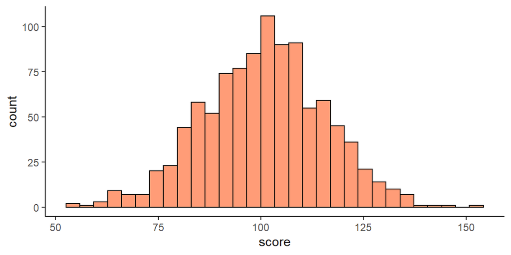

## `eval=`

The `eval=` chunk option governs the *evaluation* of the `R` code inside a chunk. By default, it is set to `TRUE` (or `T`). If it is set to `FALSE`, the code will appear but will not get run and so any code dependent on objects in this code chunk will fail.

```r
my_data2 <- tibble(
  score = rnorm(n = 1000,
                mean = 100,
                sd = 15))
```

Now there is not `my_data2` object and so the plot cannot be generated

```r
my_data2 %>%
  ggplot(aes(x = score)) +
  geom_histogram(fill = "#ff450088", colour = "black") +
  theme_classic()
```

```
## Error in eval(lhs, parent, parent): object 'my_data2' not found
```

## `include=`

```r
my_data <- tibble(
  score = rnorm(n = 1000,
                mean = 100,
                sd = 15))
```